**SYS 6018 | Fall 2020 | University of Virginia**

### Problem 6.1: Customer Segmentation with RFM (Recency, Frequency, and Monetary Value)

RFM analysis is an approach that some businesses use to understand their customers’ activities. At any point in time, a company can measure how recently a customer purchased a product (Recency), how many times they purchased a product (Frequency), and how much they have spent (Monetary Value). There are many ad-hoc attempts to segment/cluster customers based on the RFM scores (e.g., here is one based on using the customers’ rank of each dimension independently: https://joaocorreia.io/blog/rfm-analysis-increase-sales-by-segmenting-your-customers.html). In this problem you will use the clustering methods we covered in class to segment the customers.

The data for this problem can be found here: https://mdporter.github.io/SYS6018/data/RFM.csv. Cluster based on the Recency, Frequency, and Monetary value columns.

1. Implement hierarchical clustering.
   - Describe any pre-processing steps you took (e.g., scaling, distance metric)
   - State the linkage method you used with justification.
   - Show the resulting dendrogram
   - State the number of segments/clusters you used with justification.
   - Using your segmentation, are customers 1 and 100 in the same cluster?

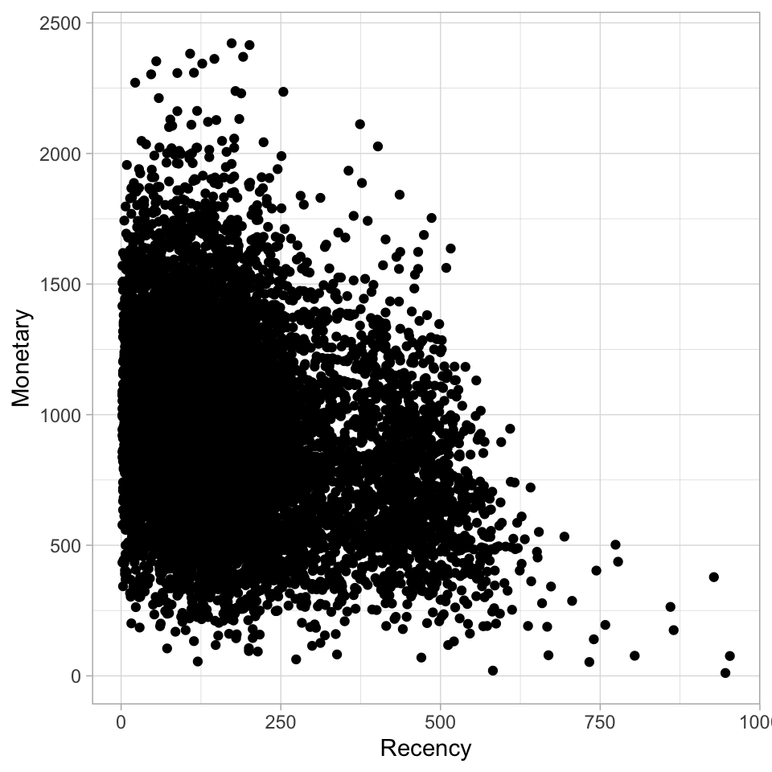

```r
data <- read.csv("RFM.csv")
dataX = dplyr::select(data, Recency, Frequency, Monetary) # extract features

ggplot(dataX) + geom_point(aes(Recency,Monetary)) + theme_light()
```

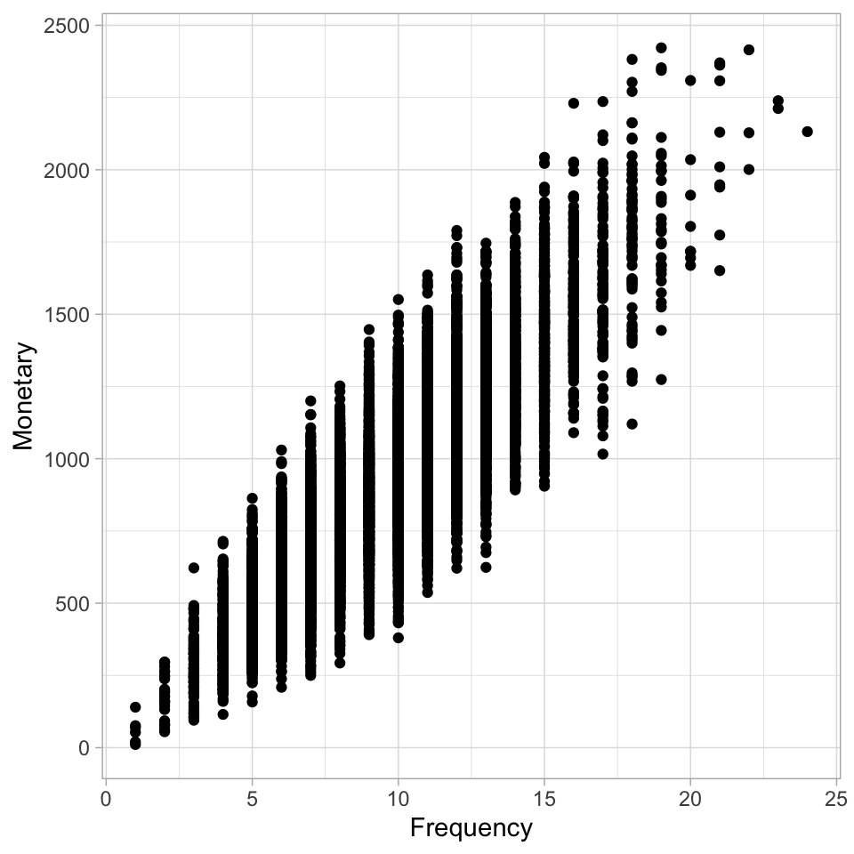

```r
ggplot(dataX) + geom_point(aes(Frequency,Monetary)) + theme_light()
```

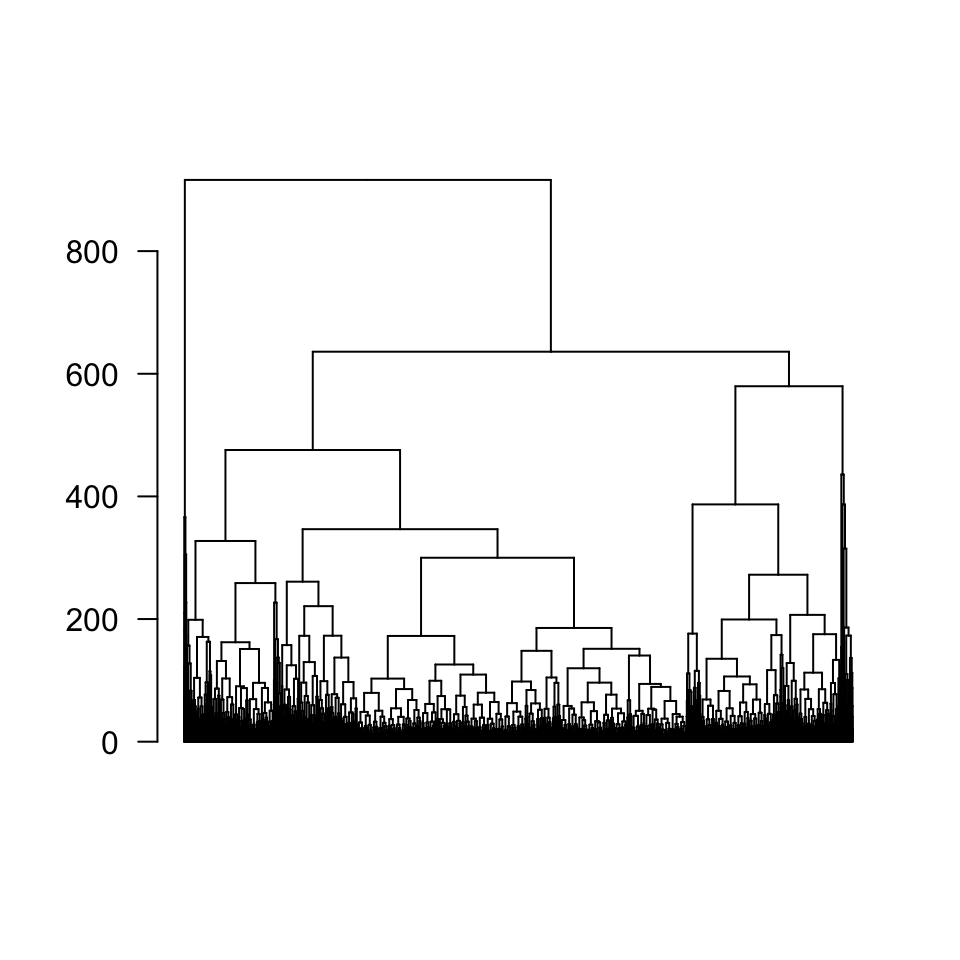

```r
#---------------------------------------------------------------------------#
#-- average linkage
#---------------------------------------------------------------------------#
#-- Calculate Distance (dissimilarity matrix)
dX = dist(dataX, method="euclidean")  # calculate distance

#-- Run hierarchical clustering
hc_average = hclust(dX, method="average")      # average linkage

#-- Plot
# plot(hc)     # basic plot
plot(as.dendrogram(hc_average), las=1, leaflab="none")
```

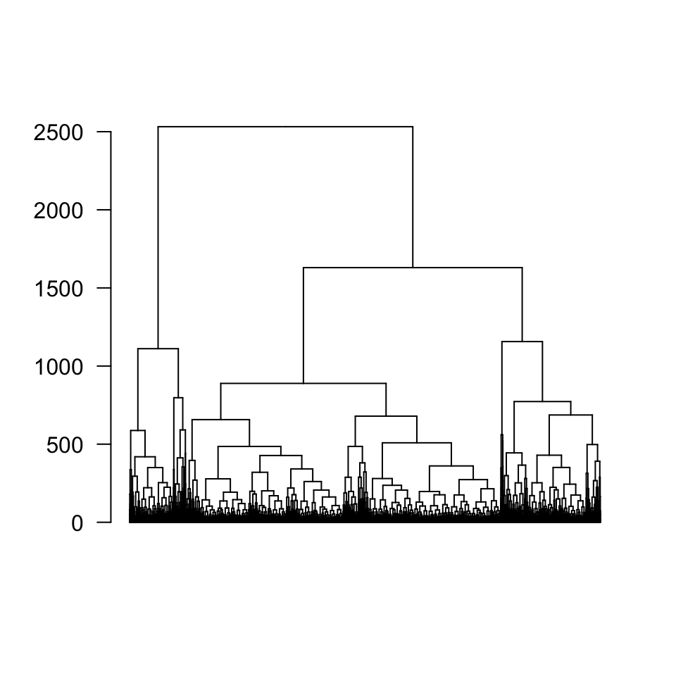

```r
#---------------------------------------------------------------------------#
#-- complete linkage
#---------------------------------------------------------------------------#
#-- Run hierarchical clustering
hc_complete = hclust(dX, method="complete")      # complete linkage

#-- Plot
# plot(hc)     # basic plot
plot(as.dendrogram(hc_complete), las=1, leaflab="none")
```

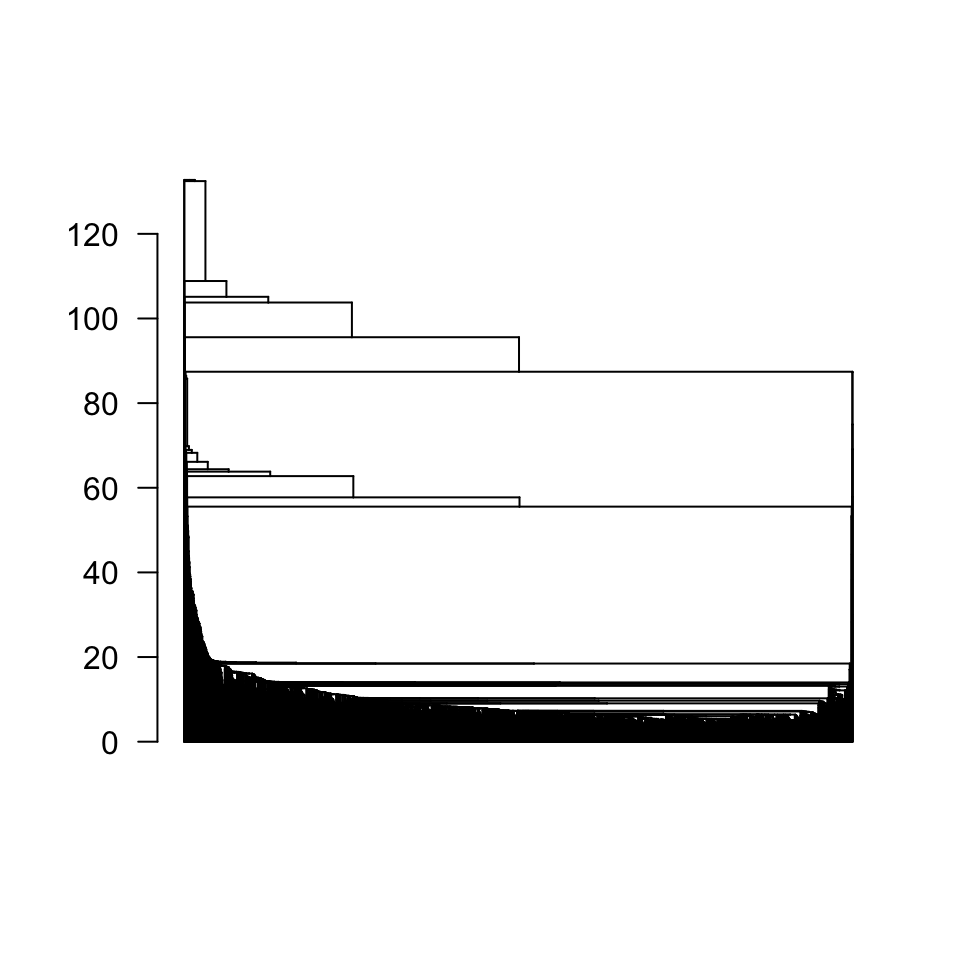

```r
#---------------------------------------------------------------------------#
#--  single linkage
#---------------------------------------------------------------------------#
#-- Run hierarchical clustering
hc_single = hclust(dX, method="single")      # single linkage

#-- Plot
# plot(hc)     # basic plot
plot(as.dendrogram(hc_single), las=1, leaflab="none")
```

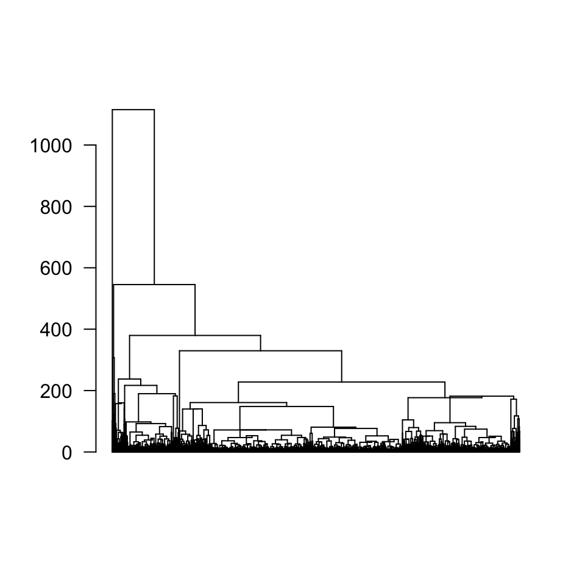

```r
#---------------------------------------------------------------------------#
#-- centroid linkage
#---------------------------------------------------------------------------#
#-- Run hierarchical clustering
hc_centroid = hclust(dX, method="centroid")      # centroid linkage

#-- Plot
# plot(hc)     # basic plot
plot(as.dendrogram(hc_centroid), las=1, leaflab="none")
```

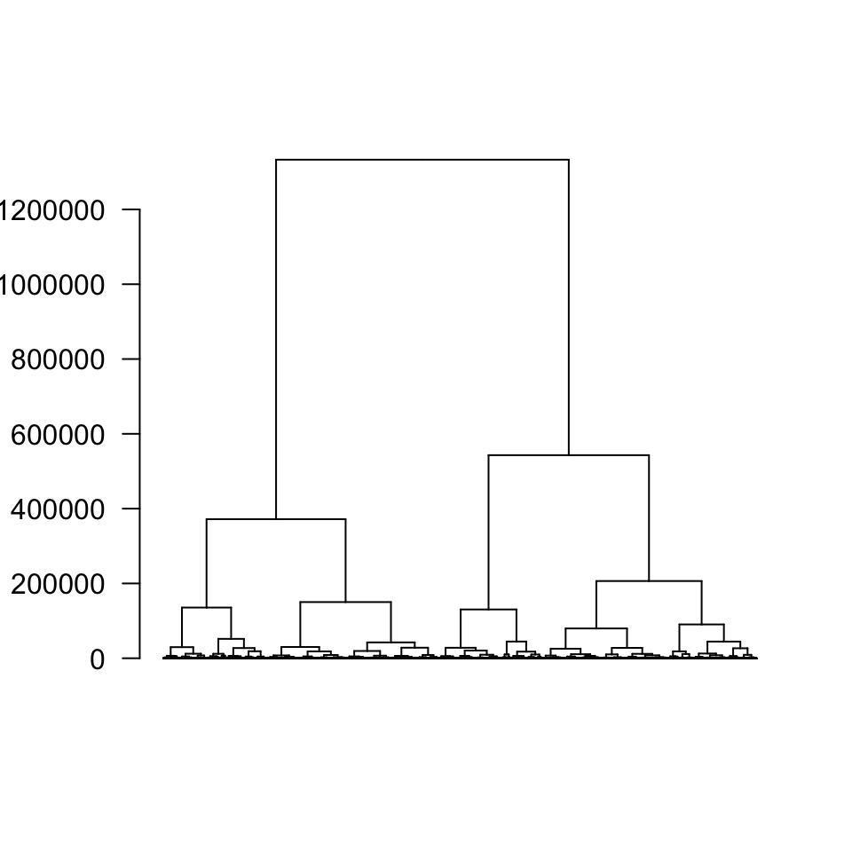

```r
#---------------------------------------------------------------------------#
#--  ward.D linkage
#---------------------------------------------------------------------------#
#-- Run hierarchical clustering
hc_ward = hclust(dX, method="ward.D")      #  ward.D linkage

#-- Plot
# plot(hc)     # basic plot
plot(as.dendrogram(hc_ward), las=1, leaflab="none") #+ geom_line(aes(color = ifelse(id ==1,"red", "black")))
```

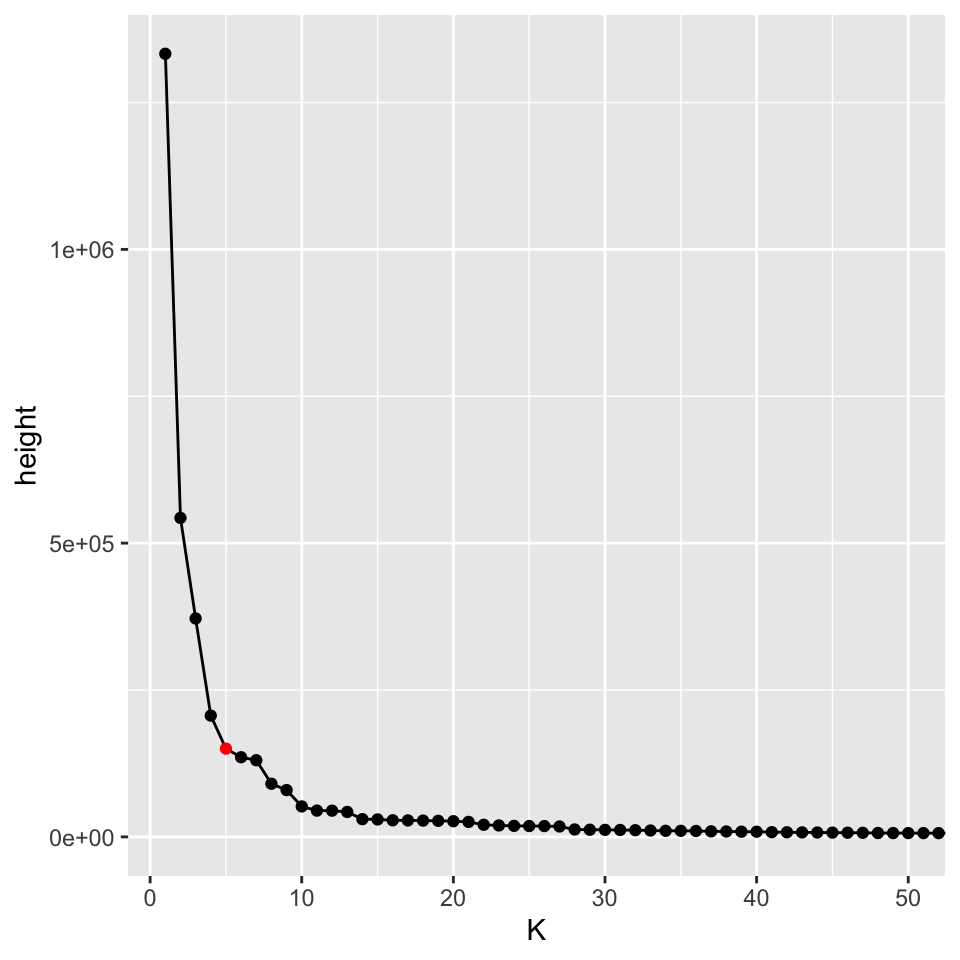

```r
#-- Guess number of clusters by height plot
# tidyverse
tibble(height = hc_ward$height, K = row_number(-height)) %>%
  ggplot(aes(K, height)) +
  geom_line() +
  geom_point(aes(color = ifelse(K == 5, "red", "black"))) +
  scale_color_identity() +
  coord_cartesian(xlim=c(1, 50))
```

```r
yhat = cutree(hc_ward, k=5)
yhat[1] == yhat[100]
```

```
#> [1] FALSE
```